# ICES_WGSFD_ToRC:SSF_A procedure for anonymising qualified geolocation datasets for the calibration of shared machine-learning models

Ifremer_SIH_JulienRodriguez

29 septembre, 2022

[figure not shown]

# 1- Context & objectives

- In the subgroup working on ToRC, some case studies were presented using machine-learning models to predict the fishing operations.
- These methods seem to be really promising and will be prospected further, but, for these models to be shared and used by the community, they have to be calibrated on representative datasets, eg datasets that will be able to represent all the variability of the fishing practices that we want to describe.
- From this perspective, the need to share consolidated data in a common database available to the community appears but it has to deal with anonymization of the information to be compliant with our confidentiality obligations.
- In this part we will provide a methodology to compile with this requirement of anonymization while maintaining a mimimal distorsion of the information contained in the data.

# 2- Data requirements and anonymisation requisites

- Following informations would be required in the final data base:
  - source: sourcing the dataset provider
  - Fishing vessel identifier: unique identifier of the vessel
  - Fishing trip identifier: unique identifier of a fishing trip. Fishing trips have to be identified before the anonymisation process because after a spatial translation it won’t be possible to link positions to a harbour or coastline.
  - DATE_TIME: timestamp, a character string coercible to POSIXct
  - Longitude: Longitude in EPSG:4326 CRS
  - Latitude: Latitude in EPSG:4326 CRS
  - Gear: An identification of the gear related to the position at least available at level 3: “NT” fort nets, “TB” for trawls….
  - FishingOperation: a qualification of the ping regarding the fishing operation than can take following values: *NA*: missing, *NotFishing*: Not a fishing operation *Fishing*: Fishing operation for active gears *Setting*: setting the gear for passive gears *Hauling*: hauling the gear for passive gears
  - Data Quality index: an index to qualify the quality of the FishingOperation flag.
- For the anonymisation to be effective, three levels have to be taken into account:
  - **Identity** The fishing vessel identifier has to be translated to an anonymous code
  - **Time** The timestamp have to be randomly translated. To keep the hierarchical and temporal information between the fishing trips, the translation will be performed using the same key for the whole dataset.
  - **Space** The positions have to be randomly translated. To ensure that the country or harbours of origin won’t be possibly recognized while keeping the geographic information undisturbed for one vessel, it will be randomly translated for each fishing vessel.
- An anonymisation of these three levels will guarantee that the geolocation information won’t be possibly associated to a vessel.

# 2- Data example

- In this report, an example is provided for a selection of 100 fishing trips from the Ifremer, RECOPESCA dataset for vessels operating nets.
- The dataset has been resampled to a constant timelapse of 15 minutes between positions.
- Fishing operations have been partially retrieved from sensors equipping some nets and have been comprehensively qualified using an algorithmic chain. For that reason we define a quality index of 2, meaning that the qualification might be doubtful.

# 3- R functions and packages

- sf package is required
- Most of the functions provided here will be available in “iapesca” package.

### Char2Time

- Function to convert a character string to POSIXct format

```r
Char2Time <- function(DateTime){
  timestamp <- as.POSIXct(strptime(DateTime, format = "%Y-%m-%d %H:%M:%S", tz = "GMT"))
  return(timestamp)
}
```

### df2sfp

- Function to convert a data.frame with identified coordinates columns to sf class

```r
df2sfp <- function(df, coords =  c("LONGITUDE", "LATITUDE"), crs = NULL){

  class.columns <- lapply(df, function(x) {class(x)})
  time.col <- unlist(lapply(class.columns, function(x) {all(x %in% c( "POSIXlt", "POSIXt" ))}))

  if(any(time.col)){

    for(i in 1:sum(time.col)){
      former.name <- colnames(df)[which(time.col)[i]]
      new.name <- "VarTime2Change"
      colnames(df)[ colnames(df) %in% former.name] <- new.name
      df$VarTime2Change <- as.character(Char2Time(df$VarTime2Change))
      colnames(df)[ colnames(df) %in% new.name] <- former.name
    }

  }

  positions <- sf::st_as_sf(df , coords = coords)
  if(is.null(crs)){
    sf::st_crs(positions) <- sf::st_crs(4326)
  }else{
    sf::st_crs(positions) <- sf::st_crs(crs)
  }
  return(positions)

}
```

### sfp2df

- Function to convert a sf points object to a data.frame

```r
sfp2df <- function(sf.points, rename.coords = NULL){

  if(!inherits(sf.points, "sf")) stop("sf.points must be a valid sf object")

  class.columns <- lapply(sf.points, function(x) {class(x)})
  time.col <- unlist(lapply(class.columns, function(x) {all(x %in% c( "POSIXlt", "POSIXt" ))}))

  if(any(time.col)){

    for(i in 1:sum(time.col)){
      former.name <- colnames(sf.points)[which(time.col)[i]]
      new.name <- "VarTime2Change"
      colnames(sf.points)[ colnames(sf.points) %in% former.name] <- new.name
      sf.points$VarTime2Change <- as.character(Char2Time(sf.points$VarTime2Change))
      colnames(sf.points)[ colnames(sf.points) %in% new.name] <- former.name
    }

  }

  df <- cbind( sf::st_set_geometry(sf.points, NULL), sf::st_coordinates(sf.points))

  if(!is.null(rename.coords)){
   if(!(is.vector(rename.coords) & length(rename.coords) == 2)) stop("rename.coords must a character vector of length 2")
    xy.colnames <- colnames(sf::st_coordinates(sf.points))[1:2]
    colnames(df)[ colnames(df) %in% xy.colnames] <- rename.coords
  }

  return(df)

}
```

### set_0nbr

- Function that returns a character string with zeros, the number of zeros is fixed so that nchar(paste0(set_0nbr(x), x)) is constant.

```r
set_0nbr <- function (x, ID.length = NA) {

    if (is.na(ID.length)) {
        ID.length <- max(nchar(x))
    }
    if (ID.length < max(nchar(x)))
        stop("With ID.length as defined, a negative number of zeros would have to be set, review this argument")
    if (length(x) == 0) {
        seq0 <- paste0(paste(rep(0, times = ID.length - nchar(x))),
            collapse = "")
    }
    else {
        seq0 <- do.call(c, lapply(x, function(arg) {
            return(paste0(paste(rep(0, times = ID.length - nchar(arg))),
                collapse = ""))
        }))
    }
    return(seq0)
}
```

### Harmonize_Ids

- Function that returns unique identifiers having constant length

```r
Harmonize_Ids <- function (Constantstring = "", index, ID.length = NA, sep = "_") {

    sep <- ifelse(Constantstring == "", "", sep)
    if (length(index) > length(unique(index)))
        stop("For the identifier to be unique, index has to be built with unique values, ex: 1:100")
    Harmonized.Ids <- paste0(Constantstring, sep, set_0nbr(index,
        ID.length), index)
    return(Harmonized.Ids)

}
```

### lonlat2UTM

- Function that returns the appropriated UTM system based on lon/lat positions. From Robin Lovelace, Geocomputation with R

```r
lonlat2UTM <-function( lonlat ){

  utm <- (floor((lonlat[1] + 180) / 6) %% 60) + 1

  if( lonlat[2] > 0){

    utm <- utm + 32600

  }else{

    utm <- utm + 32700

  }

  return(utm)

}
```

### Translate_Positions

- Function to translate positions in space

```r
Translate_Positions <- function(sf.points, Key.x = NULL, Key.y = NULL, proj = "UTM"){

  if( !proj %in% c("WorldMercator", "UTM")) stop("proj must be defined as WorldMercator, Customized, UTM")
  if(!inherits(sf.points, "sf")) stop("sf.points must be a valid sf object")

  coord.names <- colnames(sf::st_coordinates(sf.points))[1:2]

  if(proj %in% "WorldMercator"){
    planar.proj <- sf::st_crs(3395)
  }
  if(proj %in% "UTM"){
    planar.proj <- suppressWarnings(lonlat2UTM(sf::st_coordinates(sf::st_centroid(sf.points))))
  }

  pos.planar <- sf::st_transform(sf.points, planar.proj)
  pos.planar.df <- sfp2df(pos.planar, rename.coords = c("X", "Y"))

  if(!is.null(Key.x)){
    pos.planar.df$X <- pos.planar.df$X + Key.x
  }
  if(!is.null(Key.y)){
    pos.planar.df$Y <- pos.planar.df$Y + Key.y
  }

  colnames(pos.planar.df)[ colnames(pos.planar.df) %in% c("X", "Y")] <- coord.names
  pos.trans <- sf::st_transform(df2sfp(pos.planar.df, coords = coord.names, crs = planar.proj), sf::st_crs(4326))

  return(pos.trans)

}
```

# 4- Anonymizing the vessel identifier

- The first step is to change the vessel identifier while keeping the information on the different vessels in the database.
- The example below presents how to do this from a built-in example

```r
FishingVessels.Ids <- c(rep("999555", 104), rep("toto", 241),
                        rep("titi", 30), "tata", "8555",
                        "1", rep("lulu", 300), rep("t5455",100),
                        rep("h554", 10), "yeah")

### Define as factor to change the levels
FishingVessels.Ids <- as.factor(FishingVessels.Ids)
### Create an anonymisation key
VE.key <- data.frame(VE_REF = levels(FishingVessels.Ids),
                     VE_ANO = Harmonize_Ids("VE", 1:nlevels(FishingVessels.Ids), ID.length = 5))
print(VE.key)
```

```
   VE_REF   VE_ANO
1       1 VE_00001
2    8555 VE_00002
3  999555 VE_00003
4    h554 VE_00004
5    lulu VE_00005
6   t5455 VE_00006
7    tata VE_00007
8    titi VE_00008
9    toto VE_00009
10   yeah VE_00010
```

```r
### Anonymize the vessel identifiers
levels(FishingVessels.Ids) <- VE.key$VE_ANO
### Redefine as character
FishingVessels.Ids <- as.character(FishingVessels.Ids)
### Check the results
table(FishingVessels.Ids)
```

```
FishingVessels.Ids
VE_00001 VE_00002 VE_00003 VE_00004 VE_00005 VE_00006 VE_00007 VE_00008
       1        1      104       10      300      100        1       30
VE_00009 VE_00010
     241        1
```

- Now applied to the dataset

```r
head(positions)
```

```
          VE_REF   FT_REF           DATE_TIME        FOP QualIndex LONGITUDE
1210 NAVIRE_0005 17368153 2007-07-05 05:28:50 NotFishing         2 -1.145890
1211 NAVIRE_0005 17368153 2007-07-05 05:43:50 NotFishing         2 -1.145997
1212 NAVIRE_0005 17368153 2007-07-05 05:58:50 NotFishing         2 -1.146299
1213 NAVIRE_0005 17368153 2007-07-05 06:13:50 NotFishing         2 -1.151595
1214 NAVIRE_0005 17368153 2007-07-05 06:28:50 NotFishing         2 -1.182025
1215 NAVIRE_0005 17368153 2007-07-05 06:43:50 NotFishing         2 -1.219854
     LATITUDE            source gearId
1210 44.65774 IFREMER_RECOPESCA     NT
1211 44.65820 IFREMER_RECOPESCA     NT
1212 44.65779 IFREMER_RECOPESCA     NT
1213 44.66227 IFREMER_RECOPESCA     NT
1214 44.66836 IFREMER_RECOPESCA     NT
1215 44.65382 IFREMER_RECOPESCA     NT
```

```r
positions$VE_REF <- factor(as.character(positions$VE_REF))

VE.key <- data.frame(VE_REF = levels(positions$VE_REF),
                     VE_ANO = Harmonize_Ids("VE", 1:nlevels(positions$VE_REF), ID.length = 5))

levels(positions$VE_REF) <- VE.key$VE_ANO
positions$VE_REF <- as.character(positions$VE_REF)

### Check the results
table(positions$VE_REF)
```

```
VE_00001 VE_00002 VE_00003 VE_00004 VE_00005 VE_00006 VE_00007 VE_00008
     503      297      740     1395      559      153     1975     1190
VE_00009 VE_00010 VE_00011 VE_00012 VE_00013 VE_00014 VE_00015
     357      944      468     1201     2055      600     2326
```

# 5- Anonymizing the timestamp

- In this part, the time will be translated in the past using a randomly selected constant value of days from 1 to 20 000 (~55 years)

```r
former.timestamp <- Char2Time(positions$DATE_TIME)

# Set the seed for saving the random selection
set.seed(220909)

sel.days <- sample(1:20000, 1)
print(sel.days)
```

```
[1] 15846
```

```r
positions$DATE_TIME <- as.character(former.timestamp - sel.days*3600*24)

head(former.timestamp)
```

```
[1] "2007-07-05 05:28:50 GMT" "2007-07-05 05:43:50 GMT"
[3] "2007-07-05 05:58:50 GMT" "2007-07-05 06:13:50 GMT"
[5] "2007-07-05 06:28:50 GMT" "2007-07-05 06:43:50 GMT"
```

```r
head(Char2Time(positions$DATE_TIME))
```

```
[1] "1964-02-15 05:28:50 GMT" "1964-02-15 05:43:50 GMT"
[3] "1964-02-15 05:58:50 GMT" "1964-02-15 06:13:50 GMT"
[5] "1964-02-15 06:28:50 GMT" "1964-02-15 06:43:50 GMT"
```

# 6- Anonymizing the spatial information

- It is performed by vessel, so that the original harbours or coastline may be not easily retrieved from the patterns generated by different vessels.
- For each vessels, a random translation is sampled between - 2 000 and 2 000 kms.

```r
# Set the seed
set.seed(220929)

# Convert data.frame to sf object
PosSf.former <- df2sfp(positions, c("LONGITUDE", "LATITUDE"))

boats <- unique(positions$VE_REF)
boat <- boats[1]

Position.trans <- lapply(boats, function(boat){

    key.spatial <- sample(-2000:2000, 1)*1000
    new.pos <- Translate_Positions(sf.points = PosSf.former[ PosSf.former$VE_REF %in% boat, ],
                                 Key.x = key.spatial,
                                 Key.y = key.spatial
                                 )

    return(list(key = key.spatial, pos = new.pos))

})

Key.spatial <- data.frame(Boats = boats,
                          Key = do.call(rbind, lapply(Position.trans, function(x){ return(x$key) })))
PosSf.trans <- do.call(rbind, lapply(Position.trans, function(x){ return(x$pos) }))

positions.trans <- sfp2df(PosSf.trans, rename.coords = c("LONGITUDE", "LATITUDE"))

print(Key.spatial)
```

```
      Boats      Key
1  VE_00001  1430000
2  VE_00002   358000
3  VE_00003  1792000
4  VE_00004 -1632000
5  VE_00005  -630000
6  VE_00006   290000
7  VE_00007  1960000
8  VE_00008  1674000
9  VE_00009  1133000
10 VE_00010 -1656000
11 VE_00011  1772000
12 VE_00012  -966000
13 VE_00013 -1196000
14 VE_00014    43000
15 VE_00015 -1364000
```

- It has to be evaluated, if the translation may have a significant impact when calculating the covariates (speed, bearing…). It should have an impact on variables like heading or bearing but not necessarily on the derivated ones useful in the model: bearing rate, turning angle.
- Particular attention has to be brought to northern countries particulary the paths coming closer to the pole.

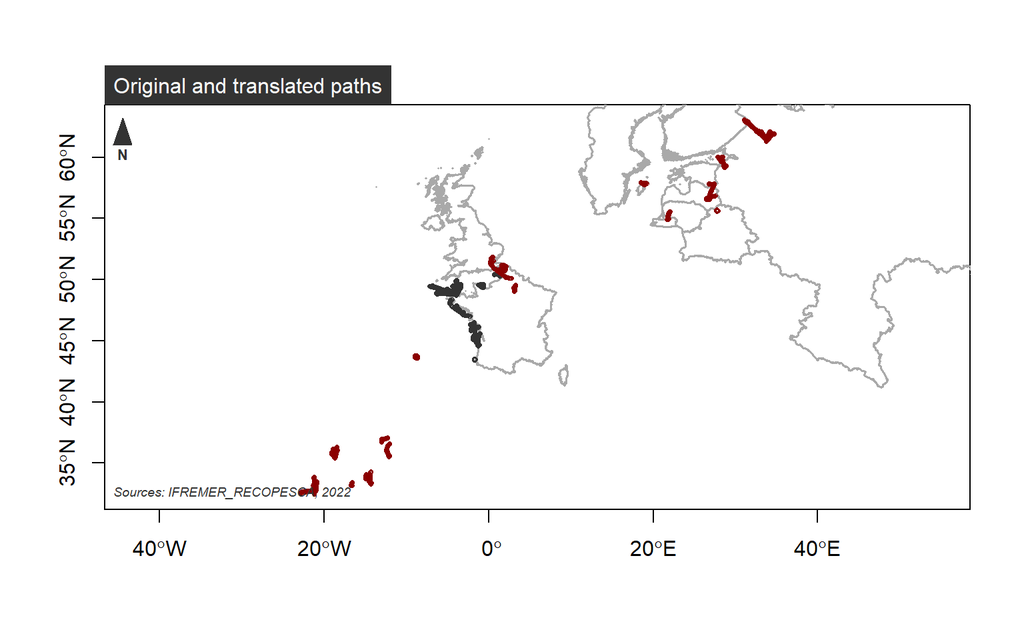